# CMSE 801 - Day 23

## Using random numbers in computational models

### Application: diffusion of particles (i.e. a "random walk")

#### April 9, 2026

## General Course Announcements

- Final version of your **project notebook** is due **April 20 by 11:59pm**.
- You can continue to work on your **slides** after that deadline and up until you present.
- Two presentation days (April 21 and April 23).
  - Locations: same room as classes
  - Your presentation will be **strictly limited to 4 minutes**.
  - You will be getting project credit for observing and rating your peers, so you are expected to attend both presentation days. Link on D2L.

## Questions/comments from Day 23 PCA

- Some issues came up with using the **seed** to control the random numbers and make the result reproducible.

## If I want reproducibility, I can specify a random *seed*

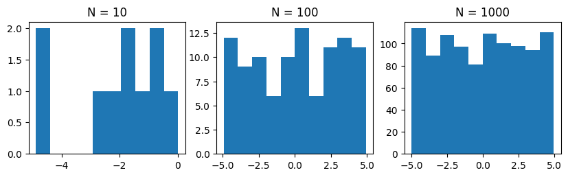

```python
import numpy as np
import matplotlib.pyplot as plt
fig, ax = plt.subplots(1, 3, figsize=(10,2.5))

np.random.seed(517) # Ensure that I always get the _same_ random numbers in the code that follows
for i,count in enumerate([10,100,1000]):
    vals = np.random.uniform(-5,5,size=count)
    ax[i].hist(vals)
    ax[i].set_title('N = %i' %count)
```

## Goals for today

- Use random numbers to simulate a "random walk" to model diffusion of particles, also called "Brownian motion"
- Simulate several "random walk" w/ different numbers of random steps
- Analyze the average properties of these simulations to compare to an observed phenomenon

## Looking forward - Day 24 PCA: Do more with random numbers, setting up for the Traveling Salesperson

- You'll explore more ways that random numbers can be used to solve problems (e.g. numerical integration)
- You'll think about the traveling salesperson problem and try to right some functions that will be needed to solve that problem